# Statistical Learning Final Project

Yaniv Bronshtein, Benjamin Barnett, Krishna Piratla

11/19/2021

**Import the necessary libraries**

```r
library(MASS)
library(ROCR)
library(tree)
library(class)
library(e1071)
library(randomForest)
library(glmnet)
library(gbm)
library(rpart)
library(gam)
```

```r
# par(mfrow=c(4,2))
```

**Import the dataset**

```r
cancer <- read.csv('breast-cancer.csv')
```

**Perform principle component analysis to minimize the number of features to be used for classification**

```r
result <- prcomp(cancer[,-c(1,2,33)], scale=TRUE)
```

**Determine the variance explained by PCA**

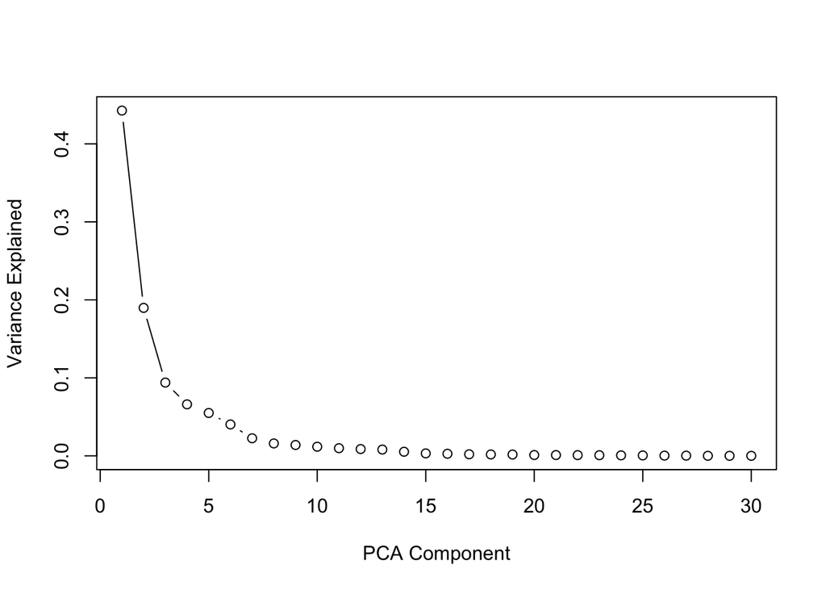

```r
var_explained <- result$sdev^2 / sum(result$sdev^2)
plot(c(1:30),
     var_explained,
     type='b',
     xlab='PCA Component',
     ylab='Variance Explained')
```

**Extract the first 7 principle components**

```r
pca <- result$x; pca <- pca[,1:7]
# cancer <- cancer[,c(2,23,24,27,28,31)]
```

**Create train and test sets for PCA and diagnosis**

```r
set.seed(1)
train <- sample(1:nrow(cancer), 0.5*nrow(cancer))

pca_train <- data.frame(pca[train,])
pca_test <- data.frame(pca[-train,])

diagnosis_train <- cancer$diagnosis[train]
diagnosis_test <- cancer$diagnosis[-train]
```

**Fit a logistic regression model and generate the roc_curve for it**

```r
glm_fit <- suppressWarnings(glm(as.factor(diagnosis_train) ~., data=pca_train, family=binomial))
glm_prb <- predict(glm_fit, pca_test, type="response")

roc_prd1 <- prediction(glm_prb, diagnosis_test)
roc_prf1 <- performance(roc_prd1,"tpr","fpr")
```

**Plot Logistic Regression roc curve**

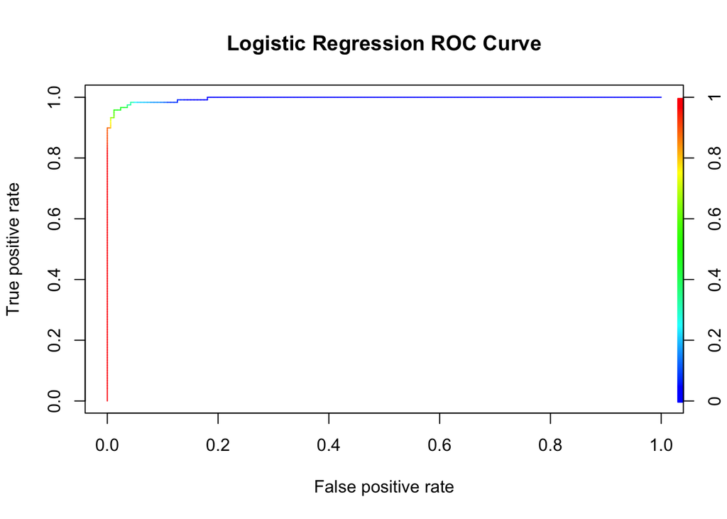

```r
plot(roc_prf1, colorize=TRUE, main="Logistic Regression ROC Curve")
```

**Get the AUC value for our ROC curve**

```r
auc1 <- as.numeric((performance(roc_prd1,"auc"))@y.values)
auc1
```

```
## [1] 0.9960514
```

**Generate the confusion matrix and compute the accuracy for logistic regression for a 0.2 threshold**

```r
glm_prd <- rep("B", 285); glm_prd[glm_prb > .2] <- "M"
c1_20 <- table(glm_prd, diagnosis_test)
a1_20 <- (table(glm_prd, diagnosis_test)[1] + table(glm_prd, diagnosis_test)[4])/285
c1_20
```

```
##        diagnosis_test
## glm_prd   B   M
##       B 155   2
##       M  11 117
```

```r
a1_20
```

```
## [1] 0.954386
```

**Generate the confusion matrix and compute the accuracy for logistic regression for a 0.5 threshold**

```r
glm_prd <- rep("B", 285); glm_prd[glm_prb > .5] <- "M"
c1_50 <- table(glm_prd, diagnosis_test)
a1_50 <- (table(glm_prd, diagnosis_test)[1] + table(glm_prd, diagnosis_test)[4])/285
c1_50
```

```
##        diagnosis_test
## glm_prd   B   M
##       B 164   6
##       M   2 113
```

```r
a1_50
```

```
## [1] 0.9719298
```

**Generate the confusion matrix and compute the accuracy for logistic regression for a 0.8 threshold**

```r
glm_prd <- rep("B", 285); glm_prd[glm_prb > .8] <- "M"
c1_80 <- table(glm_prd, diagnosis_test)
a1_80 <- (table(glm_prd, diagnosis_test)[1] + table(glm_prd, diagnosis_test)[4])/285
c1_80
```

```
##        diagnosis_test
## glm_prd   B   M
##       B 166  12
##       M   0 107
```

```r
a1_80
```

```
## [1] 0.9578947
```

**Perform Linear Discriminant analysis**

```r
lda_fit <- lda(as.factor(diagnosis_train) ~., data=pca_train)
lda_prb <- predict(lda_fit, pca_test, type="response")
```

**Generate the roc_curve and predictions for the lda model**

```r
roc_prd2 <- prediction(lda_prb$posterior[,2], diagnosis_test)
roc_prf2 <- performance(roc_prd2,"tpr","fpr")
```

**Plot the roc_curve for lda**

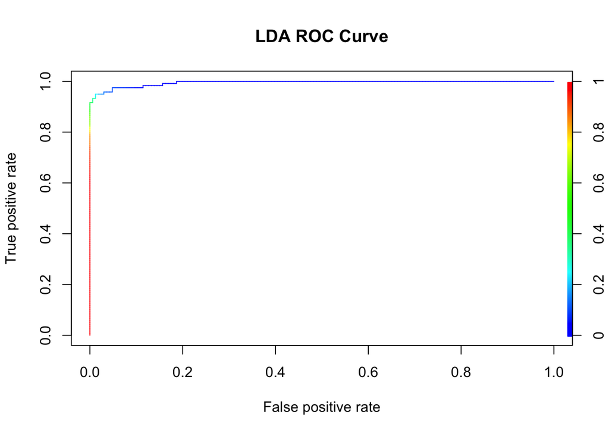

```r
plot(roc_prf2, colorize=TRUE, main="LDA ROC Curve")
```

**Get the Area under curve value from the roc_curve for lda**

```r
auc2 <- as.numeric((performance(roc_prd2,"auc"))@y.values)
```

**Generate the confusion matrix and compute the accuracy for LDA for a 0.2 threshold**

```r
lda_prd <- rep("B", 285); lda_prd[lda_prb$posterior[,2] > .2] <- "M"
c2_20 <- table(lda_prd, diagnosis_test)
a2_20 <- (table(lda_prd, diagnosis_test)[1] + table(lda_prd, diagnosis_test)[4])/285
c2_20
```

```
##        diagnosis_test
## lda_prd   B   M
##       B 164   6
##       M   2 113
```

```r
a2_20
```

```
## [1] 0.9719298
```

**Generate the confusion matrix and compute the accuracy for LDA for a 0.5 threshold**

```r
lda_prd <- rep("B", 285); lda_prd[lda_prb$posterior[,2] > .5] <- "M"
c2_50 <- table(lda_prd, diagnosis_test)
a2_50 <- (table(lda_prd, diagnosis_test)[1] + table(lda_prd, diagnosis_test)[4])/285
c2_50
```

```
##        diagnosis_test
## lda_prd   B   M
##       B 166  14
##       M   0 105
```

```r
a2_50
```

```
## [1] 0.9508772
```

**Generate the confusion matrix and compute the accuracy for LDA for a 0.8 threshold**

```r
lda_prd <- rep("B", 285); lda_prd[lda_prb$posterior[,2] > .8] <- "M"
c2_80 <- table(lda_prd, diagnosis_test)
a2_80 <- (table(lda_prd, diagnosis_test)[1] + table(lda_prd, diagnosis_test)[4])/285
c2_80
```

```
##        diagnosis_test
## lda_prd   B   M
##       B 166  25
##       M   0  94
```

```r
a2_80
```

```
## [1] 0.9122807
```

**Perform Quadratic Discriminant analysis**

```r
qda_fit <- qda(as.factor(diagnosis_train) ~., data=pca_train)
qda_prb <- predict(qda_fit, pca_test, type="response")
```

**Generate the roc_curve and predictions for the qda model**

```r
roc_prd3 <- prediction(qda_prb$posterior[,2], diagnosis_test)
roc_prf3 <- performance(roc_prd3,"tpr","fpr")
```

**Plot the roc_curve for qda**

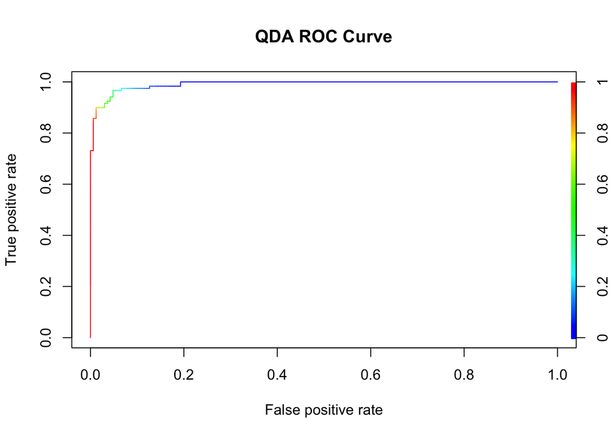

```r
plot(roc_prf3, colorize=TRUE, main="QDA ROC Curve")
```

**Get the AUC value for the roc_curve for qda**

```r
auc3 <- as.numeric((performance(roc_prd3,"auc"))@y.values)
```

**Generate the confusion matrix and compute the accuracy for QDA for a 0.2 threshold**

```r
qda_prd <- rep("B", 285); qda_prd[qda_prb$posterior[,2] > .2] <- "M"
c3_20 <- table(qda_prd, diagnosis_test)
a3_20 <- (table(qda_prd, diagnosis_test)[1] + table(qda_prd, diagnosis_test)[4])/285
c3_20
```

```
##        diagnosis_test
## qda_prd   B   M
##       B 152   3
##       M  14 116
```

```r
a3_20
```

```
## [1] 0.9403509
```

```r
qda_prd <- rep("B", 285); qda_prd[qda_prb$posterior[,2] > .5] <- "M"
c3_50 <- table(qda_prd, diagnosis_test)
a3_50 <- (table(qda_prd, diagnosis_test)[1] + table(qda_prd, diagnosis_test)[4])/285
a3_50
```

```
## [1] 0.9438596
```

```r
a3_50
```

```
## [1] 0.9438596
```

**Generate the confusion matrix and compute the accuracy for QDA for a 0.8 threshold**

```r
qda_prd <- rep("B", 285); qda_prd[qda_prb$posterior[,2] > .8] <- "M"
c3_80 <- table(qda_prd, diagnosis_test)
a3_80 <- (table(qda_prd, diagnosis_test)[1] + table(qda_prd, diagnosis_test)[4])/285
c3_80
```

```
##        diagnosis_test
## qda_prd   B   M
##       B 164  13
##       M   2 106
```

```r
a3_80
```

```
## [1] 0.9473684
```

**Train a general additive model and generate predictions**

```r
gam_fit <- gam(as.factor(diagnosis_train) ~., data=pca_train, family=binomial)
gam_prb <- predict(gam_fit, pca_test, type="response")
```

**Generate the roc_curve and predictions for the GAM**

```r
roc_prd4 <- prediction(gam_prb, diagnosis_test)
roc_prf4 <- performance(roc_prd4,"tpr","fpr")
```

**Plot the ROC curve for the GAM**

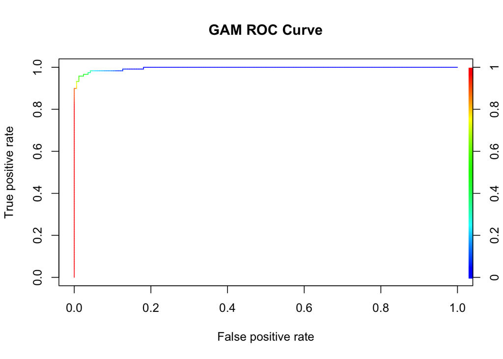

```r
plot(roc_prf4, colorize=TRUE, main="GAM ROC Curve")
```

**Get the AUC value for the GAM**

```r
auc4 <- as.numeric((performance(roc_prd4,"auc"))@y.values)
```

**Generate the confusion matrix and compute the accuracy for GAM for a 0.2 threshold**

```r
gam_prd <- rep("B", 285); gam_prd[gam_prb > .2] <- "M"
c4_20 <- table(gam_prd, diagnosis_test)
a4_20 <- (table(gam_prd, diagnosis_test)[1] + table(gam_prd, diagnosis_test)[4])/285
c4_20
```

```
##        diagnosis_test
## gam_prd   B   M
##       B 155   2
##       M  11 117
```

```r
a4_20
```

```
## [1] 0.954386
```

**Generate the confusion matrix and compute the accuracy for GAM for a 0.5 threshold**

```r
gam_prd <- rep("B", 285); gam_prd[gam_prb > .5] <- "M"
c4_50 <- table(gam_prd, diagnosis_test)
a4_50 <- (table(gam_prd, diagnosis_test)[1] + table(gam_prd, diagnosis_test)[4])/285
c4_50
```

```
##        diagnosis_test
## gam_prd   B   M
##       B 164   6
##       M   2 113
```

```r
a4_50
```

```
## [1] 0.9719298
```

**Generate the confusion matrix and compute the accuracy for GAM for a 0.8 threshold**

```r
gam_prd <- rep("B", 285); gam_prd[gam_prb > .8] <- "M"
c4_80 <- table(gam_prd, diagnosis_test)
a4_80 <- (table(gam_prd, diagnosis_test)[1] + table(gam_prd, diagnosis_test)[4])/285
c4_80
```

```
##        diagnosis_test
## gam_prd   B   M
##       B 166  12
##       M   0 107
```

```r
a4_80
```

```
## [1] 0.9578947
```

**Train a Random Forest Model and generate predictions**

```r
rnf_fit <- randomForest(as.factor(diagnosis_train) ~., data=pca_train)
rnf_prb <- predict(rnf_fit, pca_test, type="prob")
```

**Generate the ROC curve for Random Forest**

```r
roc_prd5 <- prediction(rnf_prb[,2], diagnosis_test)
roc_prf5 <- performance(roc_prd5,"tpr","fpr")
```

**Plot the ROC Curve for Random Forest**

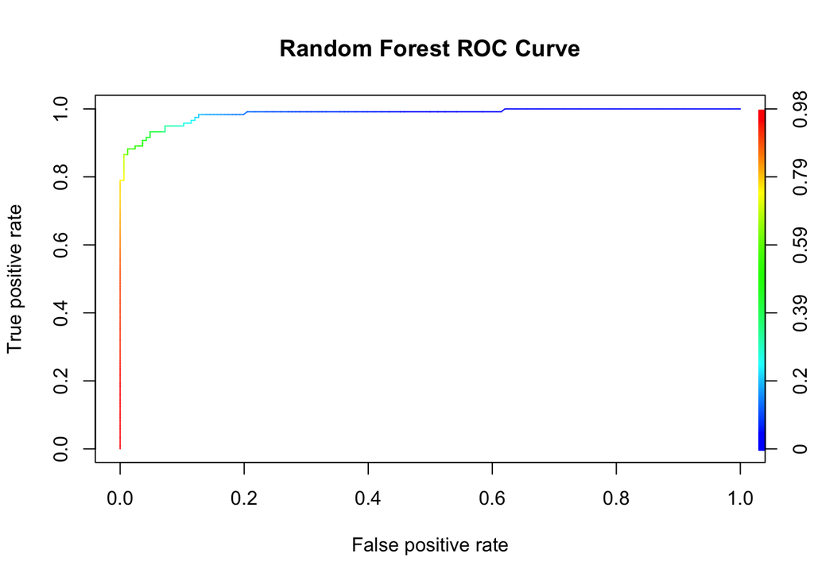

```r
plot(roc_prf5, colorize=TRUE, main="Random Forest ROC Curve")
```

**Get the AUC value for Random Forest**

```r
auc5 <- as.numeric((performance(roc_prd5,"auc"))@y.values)
```

**Generate the confusion matrix and compute the accuracy for Random Forest for a 0.2 threshold**

```r
rnf_prd <- rep("B", 285); rnf_prd[rnf_prb[,2] > .2] <- "M"
c5_20 <- table(rnf_prd, diagnosis_test)
a5_20 <- (table(rnf_prd, diagnosis_test)[1] + table(rnf_prd, diagnosis_test)[4])/285
c5_20
```

```
##        diagnosis_test
## rnf_prd   B   M
##       B 145   3
##       M  21 116
```

```r
a5_20
```

```
## [1] 0.9157895
```

**Generate the confusion matrix and compute the accuracy for Random Forest for a 0.5 threshold**

```r
rnf_prd <- rep("B", 285); rnf_prd[rnf_prb[,2] > .5] <- "M"
c5_50 <- table(rnf_prd, diagnosis_test)
a5_50 <- (table(rnf_prd, diagnosis_test)[1] + table(rnf_prd, diagnosis_test)[4])/285
c5_50
```

```
##        diagnosis_test
## rnf_prd   B   M
##       B 161  13
##       M   5 106
```

```r
a5_50
```

```
## [1] 0.9368421
```

**Generate the confusion matrix and compute the accuracy for Random Forest for a 0.8 threshold**

```r
rnf_prd <- rep("B", 285); rnf_prd[rnf_prb[,2] > .8] <- "M"
c5_80 <- table(rnf_prd, diagnosis_test)
a5_80 <- (table(rnf_prd, diagnosis_test)[1] + table(rnf_prd, diagnosis_test)[4])/285
c5_80
```

```
##        diagnosis_test
## rnf_prd   B   M
##       B 166  40
##       M   0  79
```

```r
a5_80
```

```
## [1] 0.8596491
```

**Train a Generalized Boosted Regression Model and generate predictions**

```r
bst_fit <- gbm(ifelse(diagnosis_train == 'B', 0, 1) ~., data=pca_train, distribution="bernoulli", n.trees=5000, interaction.depth=4)
bst_prb <- predict(bst_fit, pca_test, type="response")
```

```
## Using 5000 trees...
```

**Generate the ROC curve for Generalized Boosted Regression Model Model**

```r
roc_prd6 <- prediction(bst_prb, diagnosis_test)
roc_prf6 <- performance(roc_prd6,"tpr","fpr")
```

**Plot the ROC curve for Generalized Boosted Regression Model Model**

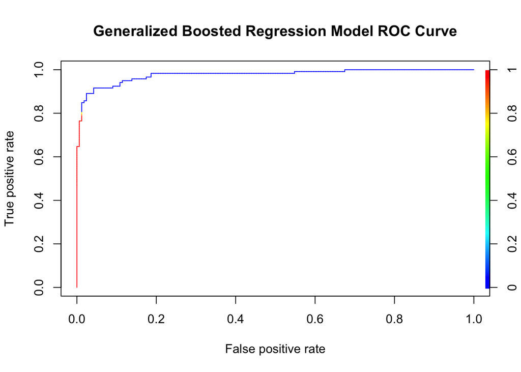

```r
plot(roc_prf6, colorize=TRUE, main="Generalized Boosted Regression Model ROC Curve")
```

**Extract the AUC value for the Generalized Boosted Regression Model Model**

```r
auc6 <- as.numeric((performance(roc_prd6,"auc"))@y.values)
```

**Generate the confusion matrix and compute the accuracy for Generalized Boosted Regression Model for a 0.2 threshold**

```r
bst_prd <- rep("B", 285); bst_prd[bst_prb > .2] <- "M"
c6_20 <- table(bst_prd, diagnosis_test)
a6_20 <- (table(bst_prd, diagnosis_test)[1] + table(bst_prd, diagnosis_test)[4])/285
c6_20
```

```
##        diagnosis_test
## bst_prd   B   M
##       B 164  24
##       M   2  95
```

```r
a6_20
```

```
## [1] 0.9087719
```

**Generate the confusion matrix and compute the accuracy for Generalized Boosted Regression Model for a 0.5 threshold**

```r
bst_prd <- rep("B", 285); bst_prd[bst_prb > .5] <- "M"
c6_50 <- table(bst_prd, diagnosis_test)
a6_50 <- (table(bst_prd, diagnosis_test)[1] + table(bst_prd, diagnosis_test)[4])/285
c6_50
```

```
##        diagnosis_test
## bst_prd   B   M
##       B 164  24
##       M   2  95
```

```r
a6_50
```

```
## [1] 0.9087719
```

**Generate the confusion matrix and compute the accuracy for Generalized Boosted Regression Model for a 0.8 threshold**

```r
bst_prd <- rep("B", 285); bst_prd[bst_prb > .8] <- "M"
c6_80 <- table(bst_prd, diagnosis_test)
a6_80 <- (table(bst_prd, diagnosis_test)[1] + table(bst_prd, diagnosis_test)[4])/285
c6_80
```

```
##        diagnosis_test
## bst_prd   B   M
##       B 164  25
##       M   2  94
```

```r
a6_80
```

```
## [1] 0.9052632
```

**Perform tuning before running the Linear Support Vector Machine algorithm**

```r
get_tuning <- tune(svm, diagnosis ~ ., data=data.frame(cbind(diagnosis = as.factor(diagnosis_train), pca_train)), kernel='linear')
```

**Train Linear Support Vector Machine Model**

```r
svm_linear <- svm(diagnosis ~ ., data=data.frame(cbind(diagnosis = as.factor(diagnosis_train), pca_train)),
kernel='linear', cost=get_tuning$best.performance, probability=TRUE)
```

**Generate the Linear SVM predictions**

```r
svm_prb <- predict(svm_linear, pca_test, probability=TRUE)
svm_prb <- attr(svm_prb, 'probabilities')[,2]
```

**Generate the roc curve for Linear SVM**

```r
roc_prd7 <- prediction(svm_prb, diagnosis_test)
roc_prf7 <- performance(roc_prd7,"tpr","fpr")
```

**Plot the ROC Curve for Linear SVM**

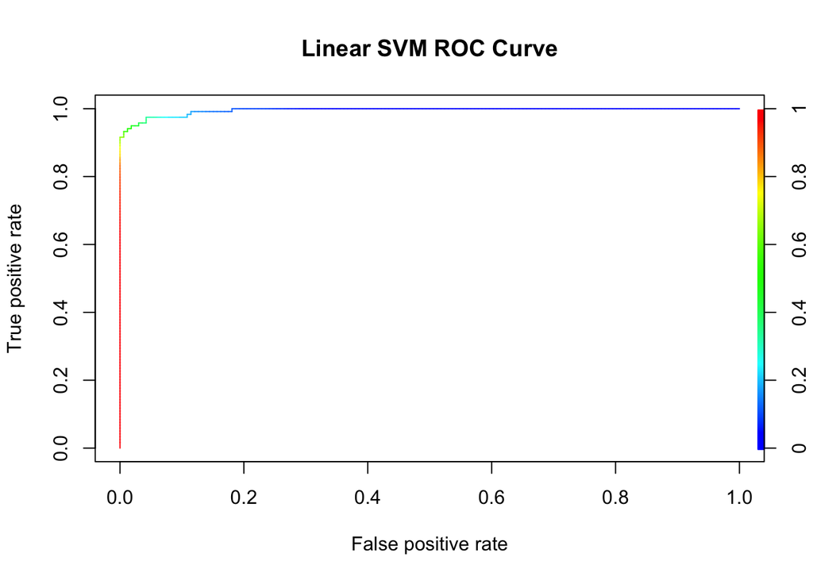

```r
plot(roc_prf7, colorize=TRUE, main="Linear SVM ROC Curve")
```

**Extract the AUC value for the Linear SVM model**

```r
auc7 <- as.numeric((performance(roc_prd7,"auc"))@y.values)
```

**Generate the confusion matrix and compute the accuracy for Linear SVM for a 0.2 threshold**

```r
svm_prd <- rep("B", 285); svm_prd[svm_prb > .2] <- "M"
c7_20 <- table(svm_prd, diagnosis_test)
a7_20 <- (table(svm_prd, diagnosis_test)[1] + table(svm_prd, diagnosis_test)[4])/285
c7_20
```

```
##        diagnosis_test
## svm_prd   B   M
##       B 148   3
##       M  18 116
```

```r
a7_20
```

```
## [1] 0.9263158
```

**Generate the confusion matrix and compute the accuracy for Linear SVM for a 0.5 threshold**

```r
svm_prd <- rep("B", 285); svm_prd[svm_prb > .5] <- "M"
c7_50 <- table(svm_prd, diagnosis_test)
a7_50 <- (table(svm_prd, diagnosis_test)[1] + table(svm_prd, diagnosis_test)[4])/285
c7_50
```

```
##        diagnosis_test
## svm_prd   B   M
##       B 164   8
##       M   2 111
```

```r
a7_50
```

```
## [1] 0.9649123
```

**Generate the confusion matrix and compute the accuracy for Linear SVM for a 0.8 threshold**

```r
svm_prd <- rep("B", 285); svm_prd[svm_prb > .8] <- "M"
c7_80 <- table(svm_prd, diagnosis_test)
a7_80 <- (table(svm_prd, diagnosis_test)[1] + table(svm_prd, diagnosis_test)[4])/285
c7_80
```

```
##        diagnosis_test
## svm_prd   B   M
##       B 166  18
##       M   0 101
```

```r
a7_80
```

```
## [1] 0.9368421
```

**Perform tuning before running the Radial Support Vector Machine algorithm**

```r
get_tuning <- tune(svm, diagnosis ~ ., data=data.frame(cbind(diagnosis = as.factor(diagnosis_train), pca_train)), kernel='radial')
```

**Train Radial Support Vector Machine Model**

```r
svm_radial <- svm(diagnosis ~ ., data=data.frame(cbind(diagnosis = as.factor(diagnosis_train), pca_train)),
kernel='radial', cost=get_tuning$best.performance, probability=TRUE)
```

**Generate the Radial SVM predictions**

```r
svm_prb <- predict(svm_radial, pca_test, probability=TRUE)
svm_prb <- attr(svm_prb, 'probabilities')[,2]
```

**Generate the roc curve for Radial SVM**

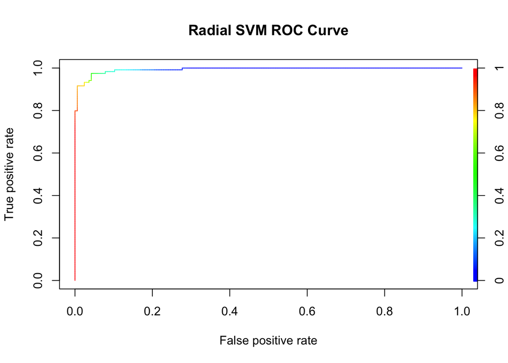

```r
roc_prd8 <- prediction(svm_prb, diagnosis_test)
roc_prf8 <- performance(roc_prd8,"tpr","fpr")
plot(roc_prf8, colorize=TRUE, main="Radial SVM ROC Curve")
```

**Extract the AUC value for the Radial SVM model**

```r
auc8 <- as.numeric((performance(roc_prd8,"auc"))@y.values)
```

**Generate the confusion matrix and compute the accuracy for Radial SVM for a 0.2 threshold**

```r
svm_prd <- rep("B", 285); svm_prd[svm_prb > .2] <- "M"
c8_20 <- table(svm_prd, diagnosis_test)
a8_20 <- (table(svm_prd, diagnosis_test)[1] + table(svm_prd, diagnosis_test)[4])/285
c8_20
```

```
##        diagnosis_test
## svm_prd   B   M
##       B 139   1
##       M  27 118
```

```r
a8_20
```

```
## [1] 0.9017544
```

**Generate the confusion matrix and compute the accuracy for Radial SVM for a 0.5 threshold**

```r
svm_prd <- rep("B", 285); svm_prd[svm_prb > .5] <- "M"
c8_50 <- table(svm_prd, diagnosis_test)
a8_50 <- (table(svm_prd, diagnosis_test)[1] + table(svm_prd, diagnosis_test)[4])/285
c8_50
```

```
##        diagnosis_test
## svm_prd   B   M
##       B 159   4
##       M   7 115
```

```r
a8_50
```

```
## [1] 0.9614035
```

```r
svm_prd <- rep("B", 285); svm_prd[svm_prb > .8] <- "M"
c8_80 <- table(svm_prd, diagnosis_test)
a8_50 <- (table(svm_prd, diagnosis_test)[1] + table(svm_prd, diagnosis_test)[4])/285
c8_50
```

```
##        diagnosis_test
## svm_prd   B   M
##       B 159   4
##       M   7 115
```

```r
a8_50
```

```
## [1] 0.9614035
```

**Plot of all ROC curves**

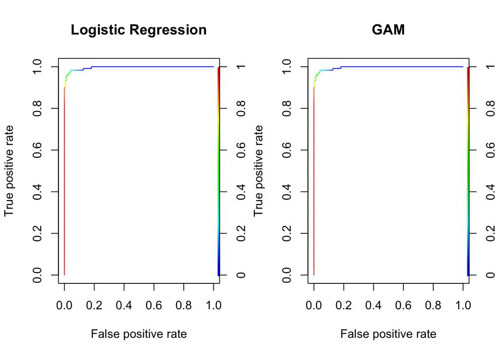

```r
par(mfrow=c(1,2))
plot(roc_prf1, colorize=TRUE, main="Logistic Regression")
plot(roc_prf4, colorize=TRUE, main="GAM")
```

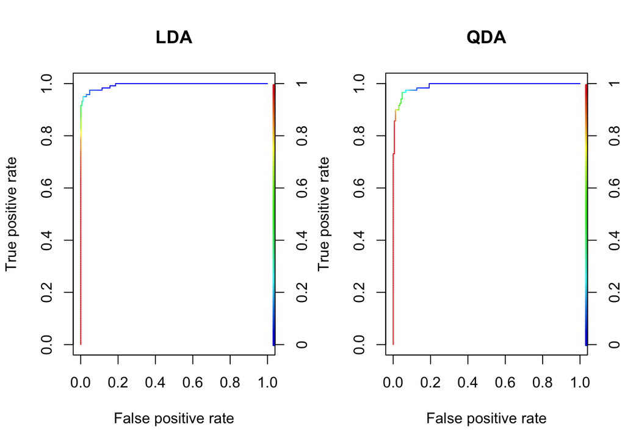

```r
par(mfrow=c(1,2))
plot(roc_prf2, colorize=TRUE, main="LDA")

plot(roc_prf3, colorize=TRUE, main="QDA")
```

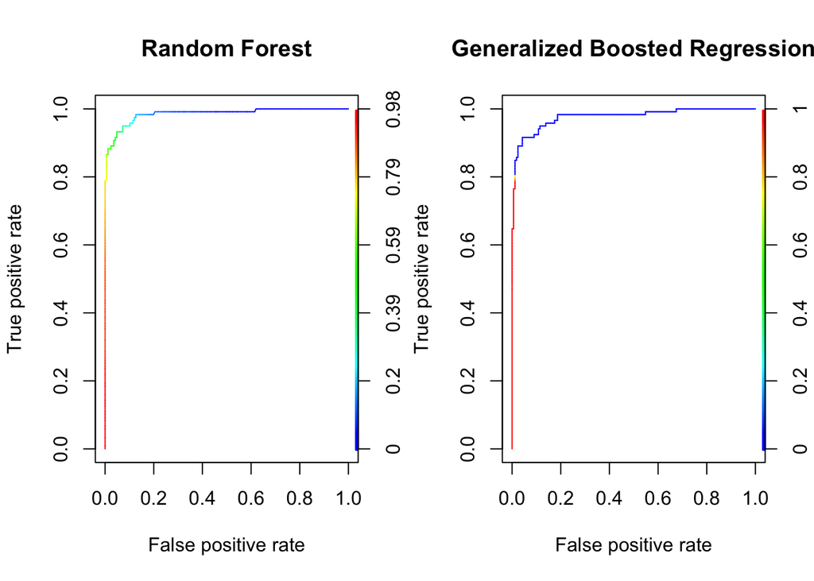

```r
par(mfrow=c(1,2))

plot(roc_prf5, colorize=TRUE, main="Random Forest")

plot(roc_prf6, colorize=TRUE, main="Generalized Boosted Regression")
```

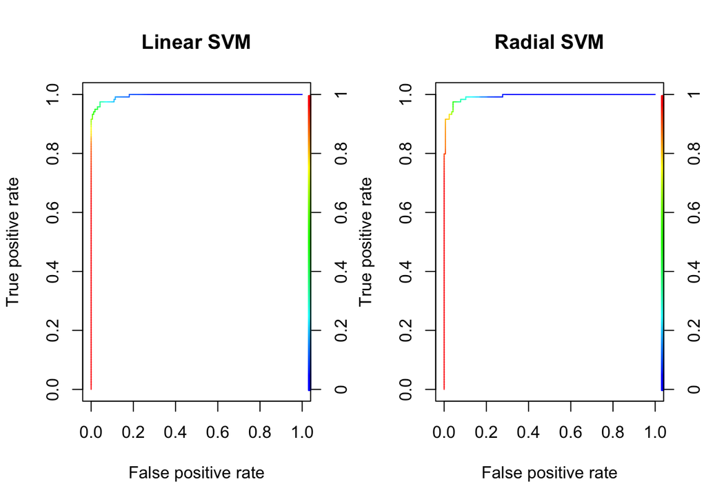

```r
par(mfrow=c(1,2))

plot(roc_prf7, colorize=TRUE, main="Linear SVM")

plot(roc_prf8, colorize=TRUE, main="Radial SVM")
```

**Plotting all confusion matrices**

```
##        diagnosis_test
## glm_prd   B   M
##       B 155   2
##       M  11 117
```

```
##        diagnosis_test
## lda_prd   B   M
##       B 164   6
##       M   2 113
```

```
##        diagnosis_test
## qda_prd   B   M
##       B 152   3
##       M  14 116
```

```
##        diagnosis_test
## gam_prd   B   M
##       B 155   2
##       M  11 117
```

```
##        diagnosis_test
## rnf_prd   B   M
##       B 145   3
##       M  21 116
```

```
##        diagnosis_test
## bst_prd   B   M
##       B 164  24
##       M   2  95
```

```
##        diagnosis_test
## svm_prd   B   M
##       B 148   3
##       M  18 116
```

```
##        diagnosis_test
## svm_prd   B   M
##       B 139   1
##       M  27 118
```